# Laboratory 06

Carmen Martín Turrero

Date : 05/06/2022

```r
library(ggplot2)
library(GoFKernel)
library(latex2exp)
library(ggpubr)
```

```r
library(ramify)
library(coda)
library(bayesplot)
```

```r
library(rjags)
```

## Exercise 1

• a well established and diffused method for detecting a disease in blood fails to detect the presence of disease in 15% of the patients that actually have the disease. • A young UniPD startUp has developed an innovative method of screening. During the qualification phase, a random sample of n = 75 patients known to have the disease is screened using the new method.

1. what is the probability distribution of y, the number of times the new method fails to detect the disease ?

The method either fails or not fails. Therefore, it follows a Binomial Distribution. Being $p$ the probability that the method fails and $n$ the number of tests, the probability distribution of y (number of failed tests) is:

$P(y|n,p) = \binom{n}{y}p^{y}(1-p)^{n-y}$

```r
# Number of tests with new method
n <- 75

# Distribution to use: binomial
```

2. on the n = 75 patients sample, the new method fails to detect the disease in y = 6 cases. What is the frequentist estimator of the failure probability of the new method ?

From the frequentist approach, the probability of failure of the new method is:

$P = \frac{y}{n} = \frac{6}{75}$

```r
# false negatives
y <- 6

# frequentist probability
prob.freq <- y/n
```

3. setup a bayesian computation of the posterior probability, assuming a beta distribution with mean value 0.15 and standard deviation 0.14. Plot the posterior distribution for y, and mark on the plot the mean value and variance

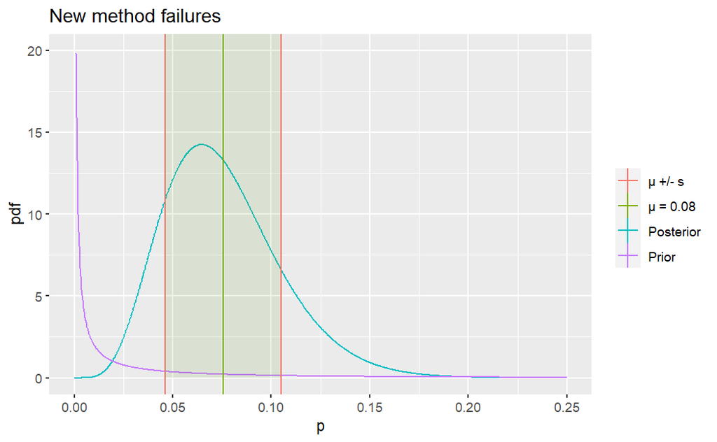

```r
# Mean and standard deviation of beta prior
p.prior <- 0.15
std.prior <- 0.14

# Beta prior parameters from the mean and the sd

a.prior <- p.prior*((p.prior*(p.prior)/std.prior**2) - 1)
b.prior <- (1 - p.prior)*((p.prior*(1 - p.prior)/std.prior**2) - 1)

# Prior
p <- seq(0,0.25,length.out = 1000)
prior = dbeta(p, a.prior, b.prior)

# A binomial likelihood and a beta prior, yield a beta posterior as a result

a.post <- a.prior + y
b.post <- b.prior + n - y

# Mean and std of the posterior
p.post <- a.post/(a.post + b.post)
std.post <- sqrt((a.post*b.post)/((a.post + b.post)**2*(a.post + b.post + 1)))

# Posterior
posterior = dbeta(p, a.post, b.post)

df.tests <- data.frame(x = p, prior = prior, posterior = posterior)


tests.plot <- ggplot() +
  geom_line(data = df.tests, aes(x=x, y=posterior, colour=('Posterior')))+
  geom_line(data = df.tests, aes(x=x, y=prior, colour = ('Prior'))) +
  geom_vline(aes(xintercept = p.post, colour = paste0('μ = ', round(p.post,2))), size = 0.5) +
  geom_vline(aes(xintercept = p.post - std.post, colour = paste0('μ +/- σ')), size = 0.5) +
  geom_vline(aes(xintercept = p.post + std.post, colour = paste0('μ +/- σ')), size = 0.5) +
  ylim(c(0, 20)) +
  geom_rect(aes(xmin=p.post - std.post, xmax=p.post + std.post, ymin=0, ymax=Inf), fill = 'chartreuse4', alpha = 0.1)+
  labs(title = "New method failures", x = "p", y = "pdf")+
  guides(color=guide_legend(NULL, order = 5))


tests.plot
```

4. Perform a test of hypothesis assuming that if the probability of failing to detect the desease in ill patients is greater or equal than 15%, the new test is no better that the traditional method. Test the sample at a 5% level of significance in the Bayesian way.

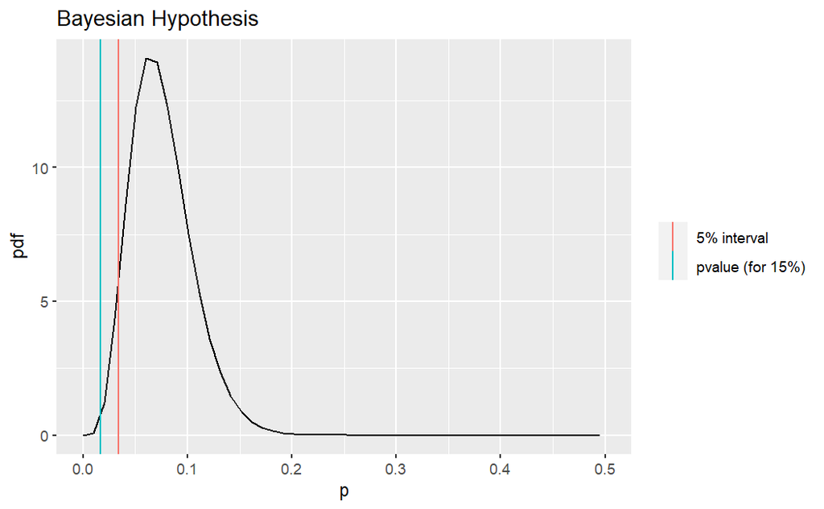

```r
# Test at a 5% level of significance
tail <- qbeta(0.05, a.post, b.post)
p <- seq(0, 1, length.out=100)
posterior = dbeta(p, a.post, b.post)

df.probs <- data.frame(x = p, post = posterior)

pvalue <- pbeta(0.15, a.post, b.post, lower.tail = FALSE)

bayesian <- ggplot() +
  geom_line(aes(x = df.probs[, 1], y = df.probs[, 2])) +
  geom_vline(aes(xintercept = tail, colour = paste0('5% interval')), size = 0.5) +
  geom_vline(aes(xintercept = pvalue, colour = paste0('pvalue (for 15%)')), size = 0.5) +
  labs(title = "Bayesian Hypothesis", x = "p", y = "pdf")+
  xlim(c(0, 0.5)) +
  guides(color=guide_legend(NULL, order = 5))



bayesian
```

```r
print(paste('The Bayesian approach leads to rejecting the null hypothesis at a 5% level of significance, since the p-value is of', round(pvalue*100,2), '%'))
```

```
[1] "The Bayesian approach leads to rejecting the null hypothesis at a 5% level of significance, since the p-value is of 1.64 %"
```

5. Perform the same hypothesis test in the classical frequentist way.

```r
# Test at a 5% level of significance
tail_freq <- qbinom(0.05, size = n, prob = 0.15)
print(tail)
```

```
[1] 0.03391152
```

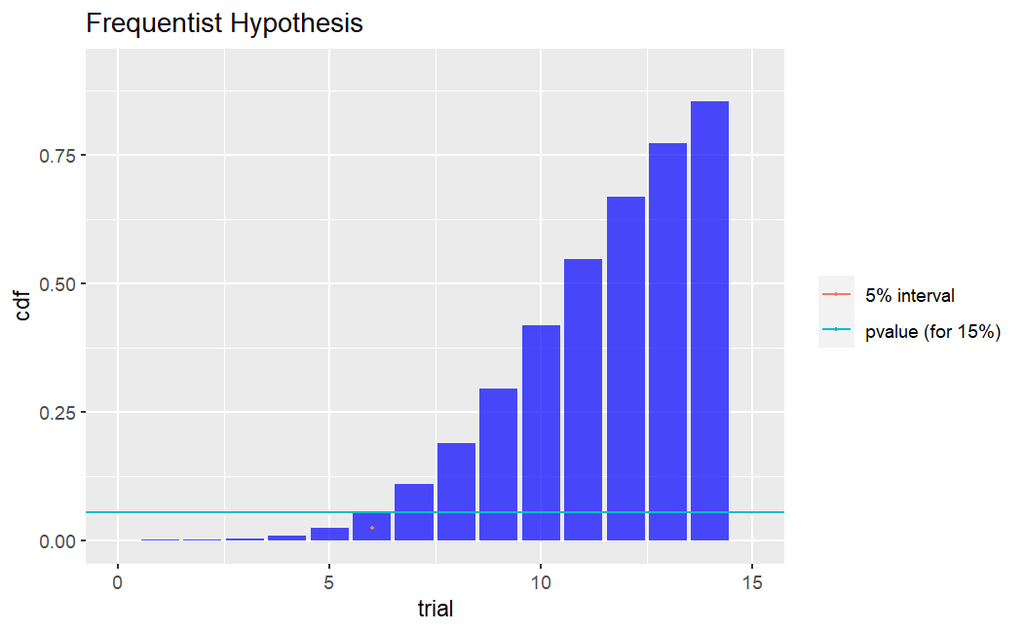

```r
trials <- c(0:n)
cdf <- pbinom(trials, size=n, prob = 0.15)

df.probs <- data.frame(x = trials, CDF = cdf)

pvalue <- pbinom(y, size=n, prob = 0.15)

frequentist <- ggplot(data=df.probs, aes(x=trials, y=CDF)) +
  geom_bar(stat="identity", fill="blue", alpha = 0.7)+
  geom_hline(aes(yintercept = pvalue, colour = paste0('pvalue (for 15%)')), size = 0.5) +
  geom_point(aes(x = tail_freq,y = cdf[6], colour = paste0('5% interval')), size = 0.5) +
  labs(title = "Frequentist Hypothesis", x = "trial", y = "cdf")+
  xlim(c(0,15))+
  guides(color=guide_legend(NULL, order = 5))



frequentist
```

```r
print(paste('The Frequentist approach leads to NOT rejecting the null hypothesis at a 5% level of significance, since the p-value is of', round(pvalue*100,2), '%'))
```

```
[1] "The Frequentist approach leads to NOT rejecting the null hypothesis at a 5% level of significance, since the p-value is of 5.44 %"
```

## Exercise 4

• analyze the data of Exercise 1 using a MCMC with JAGS (solve only point a of Ex 1)

```r
modelString <- "
model {
  # Likelihood
  y ~ dbinom(theta, n)

  # Prior
  theta ~ dbeta(a, b)
} "
```

```r
data <- list(y = y, n = n, a=a.post, b=b.post)

model <- jags.model(file = textConnection(modelString), data= data)

#burn in
update(model, n.iter = 1000)

# Number of simulated values
Nrep <- 10000

#posterior
posterior_sample <- coda.samples(model, variable.names = c("theta"), n.iter = Nrep)
```

```r
# Tables and plots
summary(posterior_sample)
plot(posterior_sample)
mcmc_hist(posterior_sample)
```

[output not shown]

## Exercise 2

• Ladislaus Josephovich Bortkiewicz was a Russian economist and statistician. He noted that the Poisson distribution can be very useful in applied statistics when describing low-frequency events in a large population. In a famous example he showed that the number of deaths by horse kick among the Prussian army follows the Poisson distribution.

• Considering the following to sets of observations taken over a fixed large time interval in two different corps:

```r
y <- c(0, 1, 2, 3, 4, '≥ 5')
n1 <- c(109, 65, 22, 3, 1, 0)
n2 <- c(144, 91, 32, 11, 2, 0)
```

1. assuming a uniform prior, compute and plot the posterior distribution for λ, the death rate over the measurement time. Determine the posterior mean, median and variance, and compute the 95% credibility interval.

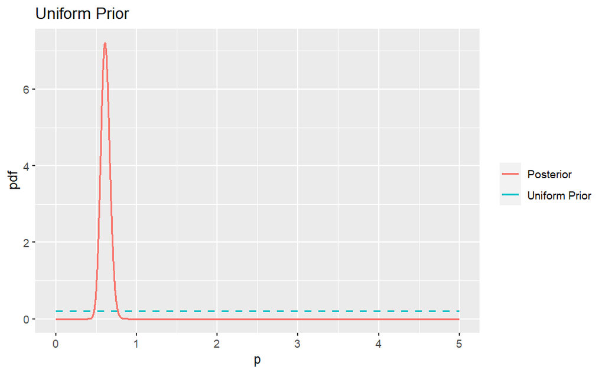

```r
tot1 <- sum(n1)
tot2 <- sum(n2)

deaths <- c(0,1,2,3,4,5)


# Posterior distribution
u.prior <- function(x){dunif(x, 0, 5)}
u.alpha <- sum(n1*deaths) + 1
u.post <- function(x){return (dgamma(x, shape = u.alpha, rate = tot1))}

# Plot
steps <- 0.002
p <- seq(0, 5, steps)

df.u <- data.frame(x = p, prior = u.prior(p), post = u.post(p))

u.plot <- ggplot() +
  geom_line(data = df.u, aes(x=x, y= prior, colour = 'Uniform Prior'), linetype ='dashed', size = 0.7) +
  geom_line(data = df.u, aes(x=x, y = post, colour = 'Posterior'), size = 0.7) +
  labs(title = "Uniform Prior", x = "p", y = "pdf") +
  guides(color=guide_legend(NULL, order = 5))

u.plot
```

```r
# Statistical quantities
u.median <- qgamma(0.5, shape = u.alpha, rate = tot1)
u.mean <- u.alpha/tot1
u.var <- u.alpha/(tot1**2)

print(paste('Median:', u.median, 'Mean:', u.mean, 'Variance:', u.var))
```

```
[1] "Median: 0.613334138689371 Mean: 0.615 Variance: 0.003075"
```

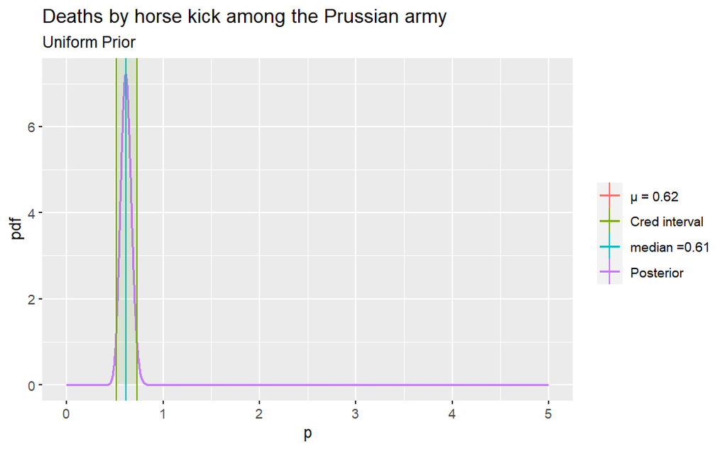

```r
# Credibility interval of 95%
u.upper <- qgamma(1-0.025, shape = u.alpha, rate = tot1)
u.lower <- qgamma(0.025, shape = u.alpha, rate = tot1)

u95.plot <- ggplot() +
  geom_line(data = df.u, aes(x=x, y = post, colour = 'Posterior'), size = 0.7) +
  geom_vline(aes(xintercept = u.mean, colour = paste0('μ = ', round(u.mean,2))), size = 0.5) +
  geom_vline(aes(xintercept = u.median, colour = paste0('median =', round(u.median,2))), size = 0.5) +
  geom_vline(aes(xintercept = u.upper, colour = paste0('Cred interval')), size = 0.5) +
  geom_vline(aes(xintercept = u.lower, colour = paste0('Cred interval')), size = 0.5) +
  #ylim(c(0, 20)) +
  geom_rect(aes(xmin=u.lower, xmax=u.upper, ymin=0, ymax=Inf), fill = 'chartreuse4', alpha = 0.1)+
  labs(title = "Deaths by horse kick among the Prussian army", subtitle = "Uniform Prior", x = "p", y = "pdf")+
  guides(color=guide_legend(NULL, order = 5))

u95.plot
```

2. assuming now a Jeffreys’ prior, g(λ) ∝ 1/√λ , with λ > 0, compute and plot the posterior distribution for λ, the death rate over the measurement time. Determine the posterior mean, median and variance, and compute the 95% credibility interval.

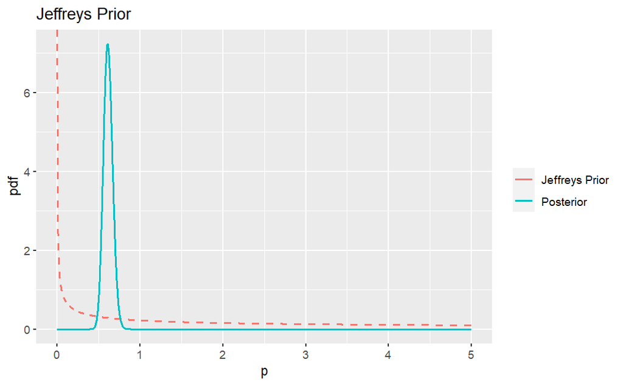

```r
# Posterior distribution
j.prior <- function(x){
  norm <- integrate(function(p){1/sqrt(p)}, lower = 0, upper = 5)$value
    return ((1/sqrt(p))/norm)
}
j.alpha <- sum(n1*deaths) + 0.5
j.post <- function(x){return (dgamma(x, shape = j.alpha, rate = tot1))}

# Plot
df.j <- data.frame(x = p, prior = j.prior(p), post = j.post(p))

j.plot <- ggplot() +
  geom_line(data = df.j, aes(x=x, y= prior, colour = 'Jeffreys Prior'), linetype ='dashed', size = 0.7) +
  geom_line(data = df.j, aes(x=x, y = post, colour = 'Posterior'), size = 0.7) +
  labs(title = "Jeffreys Prior", x = "p", y = "pdf") +
  guides(color=guide_legend(NULL, order = 5))

j.plot
```

```r
# Statistical quantities
j.median <- qgamma(0.5, shape = j.alpha, rate = tot1)
j.mean <- j.alpha/tot1
j.var <- j.alpha/(tot1**2)

print(paste('Median:', j.median, 'Mean:', j.mean, 'Variance:', j.var))
```

```
[1] "Median: 0.61083414198632 Mean: 0.6125 Variance: 0.0030625"
```

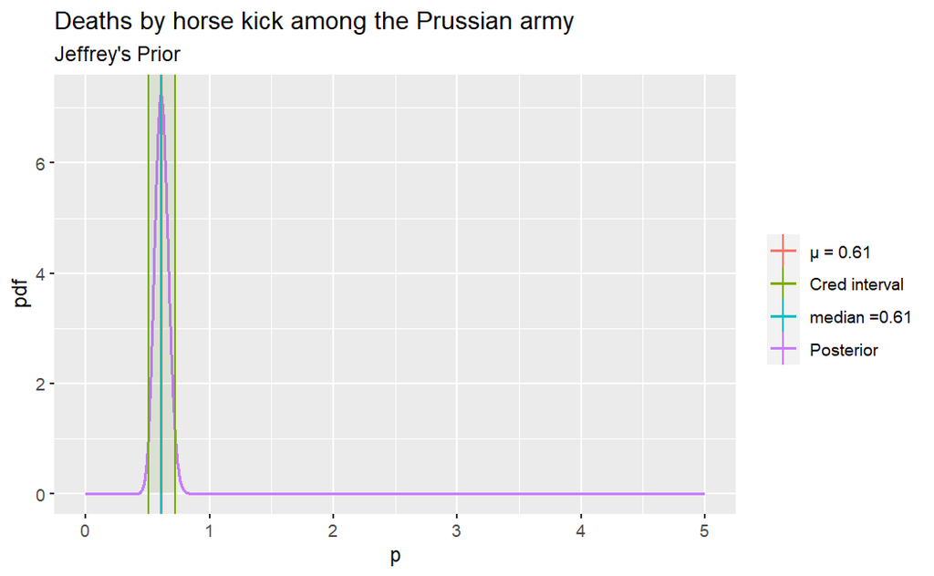

```r
# Credibility interval of 95%
j.upper <- qgamma(1-0.025, shape = j.alpha, rate = tot1)
j.lower <- qgamma(0.025, shape = j.alpha, rate = tot1)

j95.plot <- ggplot() +
  geom_line(data = df.j, aes(x=x, y = post, colour = 'Posterior'), size = 0.7) +
  geom_vline(aes(xintercept = j.mean, colour = paste0('μ = ', round(j.mean,2))), size = 0.5) +
  geom_vline(aes(xintercept = j.median, colour = paste0('median =', round(j.median,2))), size = 0.5) +
  geom_vline(aes(xintercept = j.upper, colour = paste0('Cred interval')), size = 0.5) +
  geom_vline(aes(xintercept = j.lower, colour = paste0('Cred interval')), size = 0.5) +
  #ylim(c(0, 20)) +
  geom_rect(aes(xmin=j.lower, xmax=j.upper, ymin=0, ymax=Inf), fill = 'chartreuse4', alpha = 0.1)+
  labs(title = "Deaths by horse kick among the Prussian army", subtitle = "Jeffrey's Prior", x = "p", y = "pdf")+
  guides(color=guide_legend(NULL, order = 5))

j95.plot
```

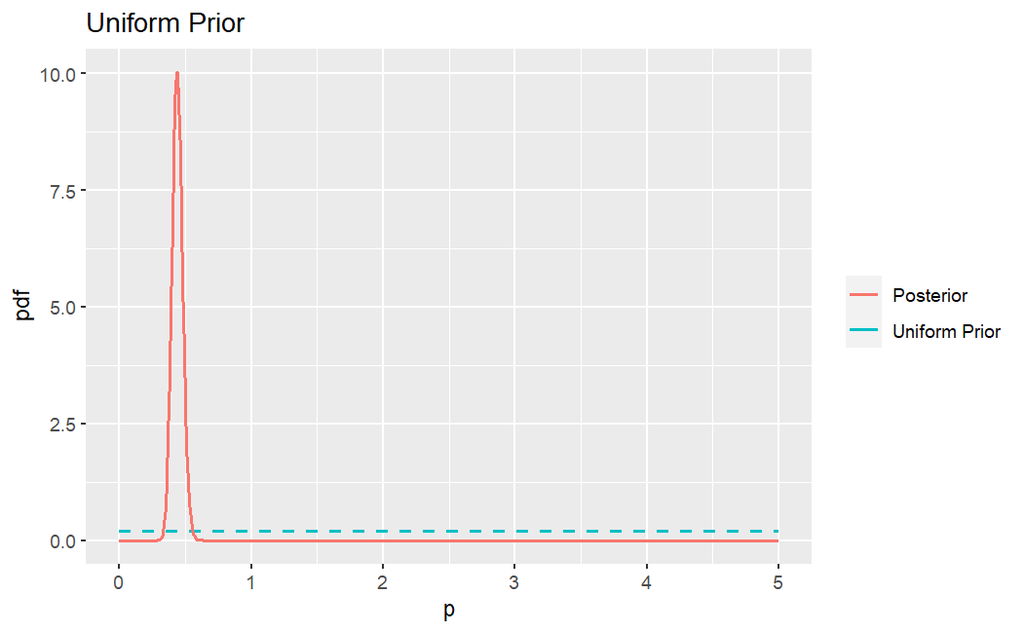

```r
# For the second dataset
# Posterior distribution
u.prior <- function(x){dunif(x, 0, 5)}
u.alpha <- sum(n1*deaths) + 1
u.post <- function(x){return (dgamma(x, shape = u.alpha, rate = tot2))}

# Plot
steps <- 0.002
p <- seq(0, 5, length.out=1/steps)

df.u <- data.frame(x = p, prior = u.prior(p), post = u.post(p))

u.plot <- ggplot() +
  geom_line(data = df.u, aes(x=x, y= prior, colour = 'Uniform Prior'), linetype ='dashed', size = 0.7) +
  geom_line(data = df.u, aes(x=x, y = post, colour = 'Posterior'), size = 0.7) +
  labs(title = "Uniform Prior", x = "p", y = "pdf") +
  guides(color=guide_legend(NULL, order = 5))

u.plot
```

```r
# Statistical quantities
u.median <- qgamma(0.5, shape = u.alpha, rate = tot2)
u.mean <- u.alpha/tot2
u.var <- u.alpha/(tot2**2)

print(paste('Median:', u.median, 'Mean:', u.mean, 'Variance:', u.var))
```

```
[1] "Median: 0.43809581334955 Mean: 0.439285714285714 Variance: 0.00156887755102041"
```

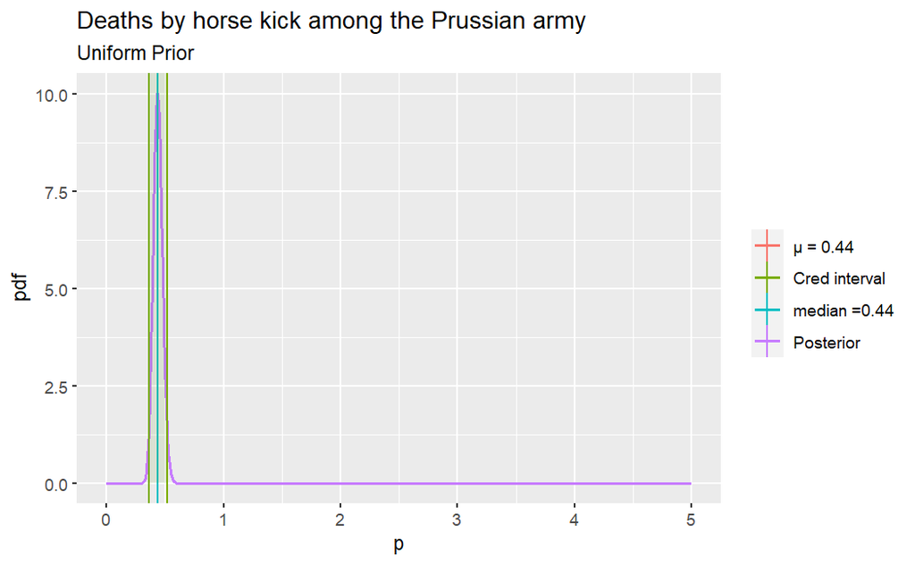

```r
# Credibility interval of 95%
u.upper <- qgamma(1-0.025, shape = u.alpha, rate = tot2)
u.lower <- qgamma(0.025, shape = u.alpha, rate = tot2)

u95.plot <- ggplot() +
  geom_line(data = df.u, aes(x=x, y = post, colour = 'Posterior'), size = 0.7) +
  geom_vline(aes(xintercept = u.mean, colour = paste0('μ = ', round(u.mean,2))), size = 0.5) +
  geom_vline(aes(xintercept = u.median, colour = paste0('median =', round(u.median,2))), size = 0.5) +
  geom_vline(aes(xintercept = u.upper, colour = paste0('Cred interval')), size = 0.5) +
  geom_vline(aes(xintercept = u.lower, colour = paste0('Cred interval')), size = 0.5) +
  #ylim(c(0, 20)) +
  geom_rect(aes(xmin=u.lower, xmax=u.upper, ymin=0, ymax=Inf), fill = 'chartreuse4', alpha = 0.1)+
  labs(title = "Deaths by horse kick among the Prussian army", subtitle = "Uniform Prior", x = "p", y = "pdf")+
  guides(color=guide_legend(NULL, order = 5))

u95.plot
```

```r
NA
NA
```

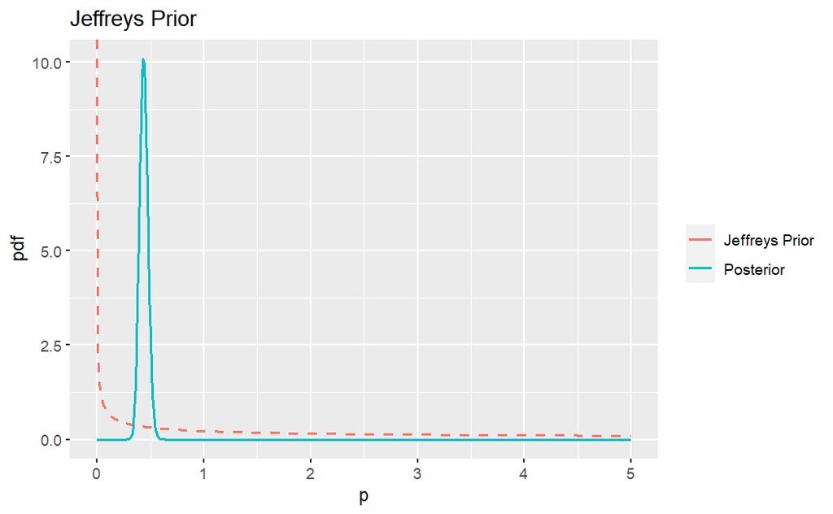

```r
# Second dataset
# Posterior distribution
j.prior <- function(x){
  norm <- integrate(function(p){1/sqrt(p)}, lower = 0, upper = 5)$value
    return ((1/sqrt(p))/norm)
}
j.alpha <- sum(n1*deaths) + 0.5
j.post <- function(x){return (dgamma(x, shape = j.alpha, rate = tot2))}

# Plot
df.j <- data.frame(x = p, prior = j.prior(p), post = j.post(p))

j.plot <- ggplot() +
  geom_line(data = df.j, aes(x=x, y= prior, colour = 'Jeffreys Prior'), linetype ='dashed', size = 0.7) +
  geom_line(data = df.j, aes(x=x, y = post, colour = 'Posterior'), size = 0.7) +
  labs(title = "Jeffreys Prior", x = "p", y = "pdf") +
  guides(color=guide_legend(NULL, order = 5))

j.plot
```

```r
# Statistical quantities
j.median <- qgamma(0.5, shape = j.alpha, rate = tot2)
j.mean <- j.alpha/tot2
j.var <- j.alpha/(tot2**2)

print(paste('Median:', j.median, 'Mean:', j.mean, 'Variance:', j.var))
```

```
[1] "Median: 0.4363101014188 Mean: 0.4375 Variance: 0.0015625"
```

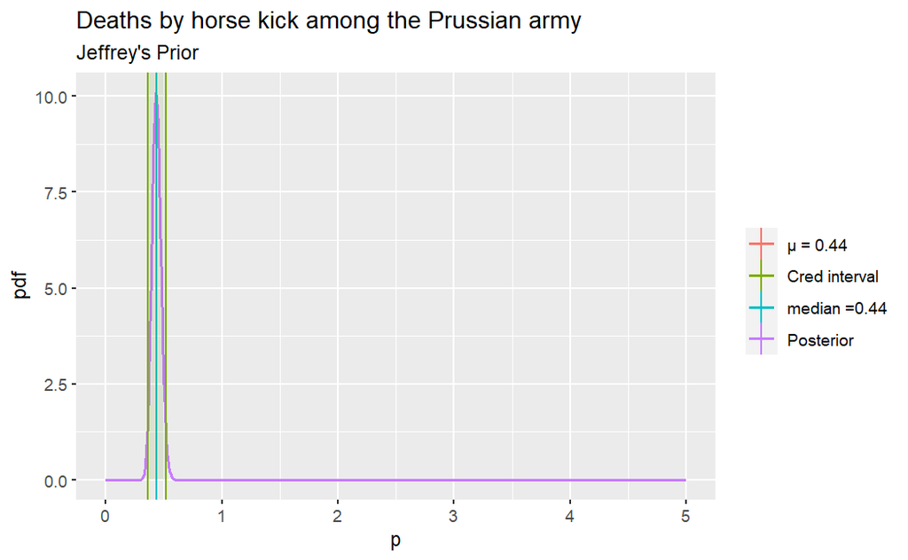

```r
# Credibility interval of 95%
j.upper <- qgamma(1-0.025, shape = j.alpha, rate = tot2)
j.lower <- qgamma(0.025, shape = j.alpha, rate = tot2)

j95.plot <- ggplot() +
  geom_line(data = df.j, aes(x=x, y = post, colour = 'Posterior'), size = 0.7) +
  geom_vline(aes(xintercept = j.mean, colour = paste0('μ = ', round(j.mean,2))), size = 0.5) +
  geom_vline(aes(xintercept = j.median, colour = paste0('median =', round(j.median,2))), size = 0.5) +
  geom_vline(aes(xintercept = j.upper, colour = paste0('Cred interval')), size = 0.5) +
  geom_vline(aes(xintercept = j.lower, colour = paste0('Cred interval')), size = 0.5) +
  #ylim(c(0, 20)) +
  geom_rect(aes(xmin=j.lower, xmax=j.upper, ymin=0, ymax=Inf), fill = 'chartreuse4', alpha = 0.1)+
  labs(title = "Deaths by horse kick among the Prussian army", subtitle = "Jeffrey's Prior", x = "p", y = "pdf")+
  guides(color=guide_legend(NULL, order = 5))

j95.plot
```

## Exercise 5

• analyze the data of Exercise 2 using a MCMC with JAGS

```r
data1 <- c(rep(0,109), rep(1,65), rep(2,22), rep(3, 3), rep(4,1))
meas1 <- length(data1)

data2 <- c(rep(0,44), rep(1, 92), rep(2,32), rep(3,11), rep(4,2))
meas2 <- length(data2)
```

```r
model_string <- "model{
  # Likelihood
  for (i in 1:n){
    y[i] ~ dpois(theta)
  }

  # Prior
  theta ~ dunif(0, 100)
}"
```

```r
# First set

data <- list(y = data1, n = meas1)

model <- jags.model(file = textConnection(model_string), data = data)

#burn in
update(model, n.iter = 1000)

# Number of simulations
N <- 100000

# Posterior
posterior_sample <- coda.samples(model, variable.names = c("theta"), n.iter = N)

# Table and plot
summary(posterior_sample)
plot(posterior_sample)
```

[output not shown]

```r
# Second set
data <- list(y = data2, n = meas2)
model <- jags.model(file = textConnection(model_string), data = data)

#burn in
update(model, n.iter = 1000)
N <- 10000
posterior_sample <- coda.samples(model, variable.names = c("theta"), n.iter = N)

# Table and plot
summary(posterior_sample)
plot(posterior_sample)
```

[output not shown]

## Exercise 3

• A study on water quality of streams, a high level of bacter X was defined as a level greater than 100 per 100 ml of stream water. n = 116 samples were taken from streams having a high environmental impact on pandas. Out of these, y = 11 had a high bacter X level.

• indicating with p the probability that a sample of water taken from the stream has a high bacter X level,

1. find the frequentist estimator for p

```r
n <- 116
y <- 11
p <- y/n

print(p)
```

```
[1] 0.09482759
```

2. using a Beta(1, 10) prior for p, calculate the posterior distribution P(p|y)

```r
# Beta prior
a <- 1; b<- 10;

a.post <- a + y
b.post <- b + n - y

p <- seq(0, 1, 0.001)

prior <- dbeta(p, shape1 = a, shape2 = b)
posterior <- dbeta(p, shape1 = a.post, shape2 = b.post)
```

3. find the bayesian estimator for p, the posterior mean and variance, and a 95% credible interval

```r
# Bayesian p
p.est <- p[which.max(posterior)]
p.mean <- a.post/(a.post+b.post)
b.variance <- a.post*b.post/(a.post+b.post)**2 /(a.post+b.post+1)

print(paste(p.mean, '+/-', b.variance))
```

```
[1] "0.094488188976378 +/- 0.000668438836877674"
```

```r
upp <- qbeta(1-0.025, shape1 = a.post, shape2 = b.post)
low <- qbeta(0.025, shape1 = a.post, shape2 = b.post)
```

4. test the hypotesis $H_{o} : p = 0.1\ versus\ H_1 : p \neq 0.1$ at 5% level of significance with both the frequentist and bayesian approach

```r
# Frequentist
p.01 <- dbinom(y, prob=0.1, size=n)
print(paste("F: p(y=11|n=116, p=0.1)=", p.01, "> 0.05, then we can't reject the hypothesis p=0.1"))
```

```
[1] "F: p(y=11|n=116, p=0.1)= 0.123287907185443 > 0.05, then we can't reject the hypothesis p=0.1"
```

```r
# Bayesian
print(paste("B: The 95% credibility interval for p: [",low, ",", upp,"] and p=0.1 lies in that interval. Therefore, we can't reject the hypothesis."))
```

```
[1] "B: The 95% credibility interval for p: [ 0.0501852163002454 , 0.150837921271285 ] and p=0.1 lies in that interval. Therefore, we can't reject the hypothesis."
```

• a new measurement, performed one month later on n = 165 water samples, gives y = 9 high bacter X level

5. find the frequentist estimator for p

```r
n <- 165
y <- 9
p <- y/n

print(p)
```

```
[1] 0.05454545
```

6. find a bayesian estimator for p, assuming both a Beta(1, 10) prior for p, and assuming the posterior probability of the older measurement as the prior for the new one.

```r
# Beta prior
a <- 1; b<- 10;

a.post <- a + y
b.post <- b + n - y

p <- seq(0, 1, 0.001)

prior <- dbeta(p, shape1 = a, shape2 = b)
posterior <- dbeta(p, shape1 = a.post, shape2 = b.post)

p.est <- p[which.max(posterior)]
print(paste('Bayesian estimation with beta prior, p =', p.est))
```

```
[1] "Bayesian estimation with beta prior, p = 0.052"
```

```r
# Now we use as prior the previous posterior
y1 <- 11; n1 <- 116;
a.post2 <- 1 + y + y1
b.post2 <- 10 + n - y + n1 - y1
posterior2.new <- dbeta(p, a.post2, b.post2)

p.est2 <- p[which.max(posterior2.new)]
print(paste('Bayesian estimation with previous estimation prior, p =', p.est2))
```

```
[1] "Bayesian estimation with previous estimation prior, p = 0.069"
```

7. find the bayesian estimator for p, the posterior mean and variance, and a 95% credible interval

```r
p.mean <- a.post2/(a.post2+b.post2)
b.variance <- a.post2*b.post2/(a.post2+b.post2)**2/(a.post2+b.post2+1)
print(paste('mean:', p.mean, 'var:', b.variance))
```

```
[1] "mean: 0.0719178082191781 var: 0.000227800809147193"
```

```r
low <- qbeta(0.025, a.post2, b.post2)
upp <- qbeta(1-0.025, a.post2, b.post2)
print(paste("95% credibility interval for p: [", low, ",", upp,"]"))
```

```
[1] "95% credibility interval for p: [ 0.0452235636236437 , 0.104151949413949 ]"
```

8. test the hypotesis $H_o : p = 0.1\ versus\ H_1 : p \neq 0.1$ at 5% level of significance with both the frequentist and bayesian approach

```r
# Frequentist
p.01 <- dbinom(y, prob=0.1, size=n)
print(paste('F: p(Y=9|n=165, p=0.1)=', p.01, '< 0.05, then we can reject the hypothesis p=0.1'))
```

```
[1] "F: p(Y=9|n=165, p=0.1)= 0.0145545429905597 < 0.05, then we can reject the hypothesis p=0.1"
```

```r
# Bayesian
print('B: By taking as prior the posterior of the previous study we cannot reject the hypothesis p=0.1')
```

```
[1] "B: By taking as prior the posterior of the previous study we cannot reject the hypothesis p=0.1"
```

## Exercise 6

• analyze the data of Exercise 3 using a MCMC with JAGS (solve point b and c)

```r
modelString <- "
model {
  # Likelihood
  y ~ dbinom(theta, n)

  # Prior
  theta ~ dbeta(1, 10)
} "
```

```r
data <- list(y = y, n = n)
model <- jags.model(file = textConnection(modelString), data=data)

#burn in
update(model, n.iter = 1000)
N <- 10000
posterior_sample <- coda.samples(model, variable.names = c("theta"), n.iter = N)

# results
summary(posterior_sample)
plot(posterior_sample)
```

[output not shown]